[figure not shown]

Predictive Modeling with Linear Regression

Project

# Problem Statement

## Business Context

An over-the-top (OTT) media service is a media service offered directly to viewers via the internet. The term is most synonymous with subscription-based video-on-demand services that offer access to film and television content, including existing series acquired from other producers, as well as original content produced specifically for the service. They are typically accessed via websites on personal computers, apps on smartphones and tablets, or televisions with integrated Smart TV platforms.

Presently, OTT services are at a relatively nascent stage and are widely accepted as a trending technology across the globe. With the increasing change in customers' social behavior, which is shifting from traditional subscriptions to broadcasting services and OTT on-demand video and music subscriptions every year, OTT streaming is expected to grow at a very fast pace. The global OTT market size was valued at $121.61 billion in 2019 and is projected to reach $1,039.03 billion by 2027, growing at a CAGR of 29.4% from 2020 to 2027. The shift from television to OTT services for entertainment is driven by benefits such as on-demand services, ease of access, and access to better networks and digital connectivity.

With the outbreak of COVID-19, OTT services are striving to meet the growing entertainment appetite of viewers, with some platforms already experiencing a 46% increase in consumption and subscriber count as viewers seek fresh content. With innovations and advanced transformations, which will enable the customers to access everything they want in a single space, OTT platforms across the world are expected to increasingly attract subscribers on a concurrent basis.

## Objective

ShowTime is an OTT service provider and offers a wide variety of content (movies, web shows, etc.) for its users. They want to determine the driver variables for first-day content viewership so that they can take necessary measures to improve the viewership of the content on their platform. Some of the reasons for the decline in viewership of content would be the decline in the number of people coming to the platform, decreased marketing spend, content timing clashes, weekends and holidays, etc. They have hired you as a Data Scientist, shared the data of the current content on their platform, and asked you to analyze the data and come up with a linear regression model to determine the driving factors for first-day viewership.

## Data Dictionary

- **Visitors**: Average number of visitors, in millions, to the platform in the past week
- **Ad_Impressions**: Number of ad impressions, in millions, across all ad campaigns for the content (running and completed)
- **Major_Sports_Event**: Any major sports event on the day
- **Genre**: Genre of the content
- **Dayofweek**: Day of the release of the content
- **Season**: Season of the release of the content
- **Views_trailer**: Number of views, in millions, of the content trailer
- **Views_content**: Number of first-day views, in millions, of the content

## Importing Libraries

```python
import numpy as np
import pandas as pd

import matplotlib.pyplot as plt
import seaborn as sns

from scipy import stats

from sklearn.model_selection import train_test_split
from sklearn.linear_model import LinearRegression

import statsmodels.api as sm
from statsmodels.stats.outliers_influence import variance_inflation_factor
```

## Loading Dataset

```python
from google.colab import drive
drive.mount('/content/drive')
```

```python
df = pd.read_csv("/content/drive/MyDrive/ShowTime/ottdata.csv")
```

## Data Overview

### Display first few rows

```python
df.head()
```

|  | visitors | ad_impressions | major_sports_event | genre | dayofweek | season | views_trailer | views_content |
| --- | --- | --- | --- | --- | --- | --- | --- | --- |
| 0 | 1.67 | 1113.81 | 0 | Horror | Wednesday | Spring | 56.70 | 0.51 |
| 1 | 1.46 | 1498.41 | 1 | Thriller | Friday | Fall | 52.69 | 0.32 |
| 2 | 1.47 | 1079.19 | 1 | Thriller | Wednesday | Fall | 48.74 | 0.39 |
| 3 | 1.85 | 1342.77 | 1 | Sci-Fi | Friday | Fall | 49.81 | 0.44 |
| 4 | 1.46 | 1498.41 | 0 | Sci-Fi | Sunday | Winter | 55.83 | 0.46 |

### Display last few rows

```python
df.tail()
```

|  | visitors | ad_impressions | major_sports_event | genre | dayofweek | season | views_trailer | views_content |
| --- | --- | --- | --- | --- | --- | --- | --- | --- |
| 995 | 1.58 | 1311.96 | 0 | Romance | Friday | Fall | 48.58 | 0.36 |
| 996 | 1.34 | 1329.48 | 0 | Action | Friday | Summer | 72.42 | 0.56 |
| 997 | 1.62 | 1359.80 | 1 | Sci-Fi | Wednesday | Fall | 150.44 | 0.66 |
| 998 | 2.06 | 1698.35 | 0 | Romance | Monday | Summer | 48.72 | 0.47 |
| 999 | 1.36 | 1140.23 | 0 | Comedy | Saturday | Summer | 52.94 | 0.49 |

### Shape

```python
df.shape
```

```
(1000, 8)
```

### Data Types

```python
df.info()
```

```
<class 'pandas.core.frame.DataFrame'>
RangeIndex: 1000 entries, 0 to 999
Data columns (total 8 columns):
 #   Column              Non-Null Count  Dtype
---  ------              --------------  -----
 0   visitors            1000 non-null   float64
 1   ad_impressions      1000 non-null   float64
 2   major_sports_event  1000 non-null   int64
 3   genre               1000 non-null   object
 4   dayofweek           1000 non-null   object
 5   season              1000 non-null   object
 6   views_trailer       1000 non-null   float64
 7   views_content       1000 non-null   float64
dtypes: float64(4), int64(1), object(3)
memory usage: 62.6+ KB
```

### Unique Values

```python
df.nunique()
```

|  | 0 |
| --- | --- |
| visitors | 56 |
| ad_impressions | 80 |
| major_sports_event | 2 |
| genre | 8 |
| dayofweek | 7 |
| season | 4 |
| views_trailer | 799 |
| views_content | 61 |

**dtype:** int64

### Duplicate Values

```python
df.duplicated().sum()
```

```
np.int64(0)
```

### Missing Values

```python
df.isnull().sum()
```

|  | 0 |
| --- | --- |
| visitors | 0 |
| ad_impressions | 0 |
| major_sports_event | 0 |
| genre | 0 |
| dayofweek | 0 |
| season | 0 |
| views_trailer | 0 |
| views_content | 0 |

**dtype:** int64

### Outlier Treatment

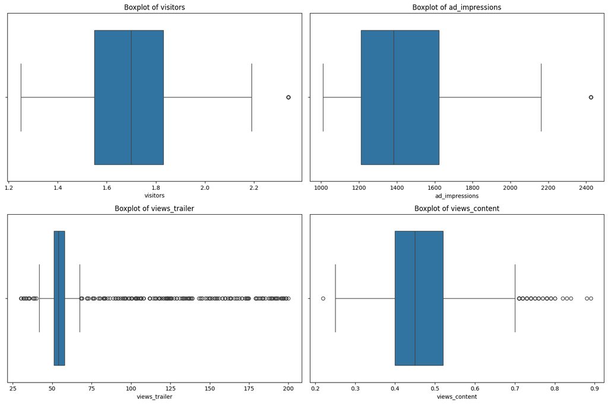

```python
# Check Outliers
num_cols = ['visitors', 'ad_impressions', 'views_trailer', 'views_content']

plt.figure(figsize=(15, 10))
for i, col in enumerate(num_cols):
    plt.subplot(2, 2, i + 1)
    sns.boxplot(x=df[col])
    plt.title(f'Boxplot of {col}')

plt.tight_layout()
plt.show()
```

**Observation**

## Exploratory Data Analysis

### Statistical Summary

```python
df.describe().T
```

|  | count | mean | std | min | 25% | 50% | 75% | max |
| --- | --- | --- | --- | --- | --- | --- | --- | --- |
| visitors | 1000.0 | 1.70429 | 0.231973 | 1.25 | 1.5500 | 1.70 | 1.830 | 2.34 |
| ad_impressions | 1000.0 | 1434.71229 | 289.534834 | 1010.87 | 1210.3300 | 1383.58 | 1623.670 | 2424.20 |
| major_sports_event | 1000.0 | 0.40000 | 0.490143 | 0.00 | 0.0000 | 0.00 | 1.000 | 1.00 |
| views_trailer | 1000.0 | 66.91559 | 35.001080 | 30.08 | 50.9475 | 53.96 | 57.755 | 199.92 |
| views_content | 1000.0 | 0.47340 | 0.105914 | 0.22 | 0.4000 | 0.45 | 0.520 | 0.89 |

### Univariate Analysis

#### Content Views

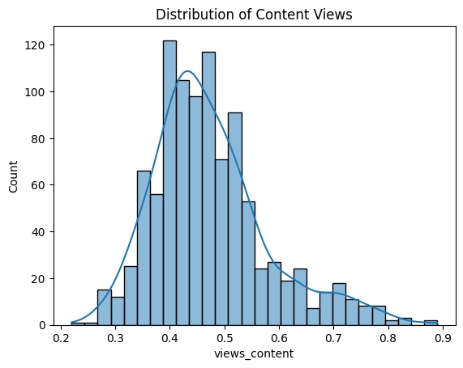

```python
sns.histplot(df["views_content"], kde=True)
plt.title("Distribution of Content Views")
plt.show()
```

**Observation**

- The distribution of first-day content views appears reasonably spread across the dataset.
- Most content receives moderate levels of viewership, while only a few pieces of content achieve exceptionally high viewership.
- No severe skewness is observed, indicating that both low-performing and high-performing content are adequately represented in the dataset.
- The variability in viewership suggests that multiple factors may be influencing content performance.

#### Visitors

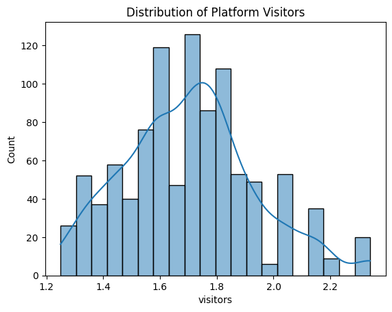

```python
sns.histplot(df["visitors"], kde=True)
plt.title("Distribution of Platform Visitors")
plt.show()
```

**Observations:**

#### Ad Impressions

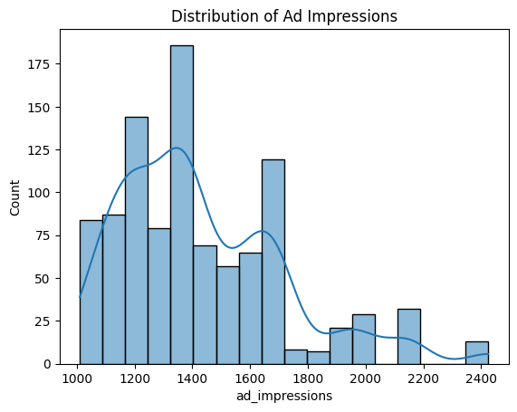

```python
sns.histplot(df["ad_impressions"], kde=True)
plt.title("Distribution of Ad Impressions")
plt.show()
```

**Observations:**

- Ad impressions show variation across content releases, indicating differences in marketing efforts.
- Most content receives a moderate number of ad impressions, while a smaller number of campaigns receive significantly higher exposure.
- The distribution suggests that marketing resources are not allocated equally across all content.
- Further analysis is required to determine whether increased advertising directly translates into higher content viewership.

#### Trailer Views

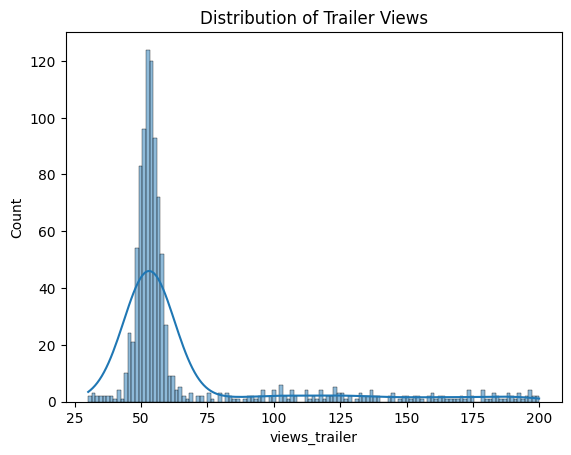

```python
sns.histplot(df["views_trailer"], kde=True)
plt.title("Distribution of Trailer Views")
plt.show()
```

**Observations:**

- Trailer views are spread across a broad range, indicating varying levels of audience interest before release.
- Some content generates significantly higher trailer engagement than others.
- The presence of highly viewed trailers suggests strong pre-release buzz for certain content.
- Trailer views are expected to be an important predictor of first-day content performance.

#### Genre Distribution

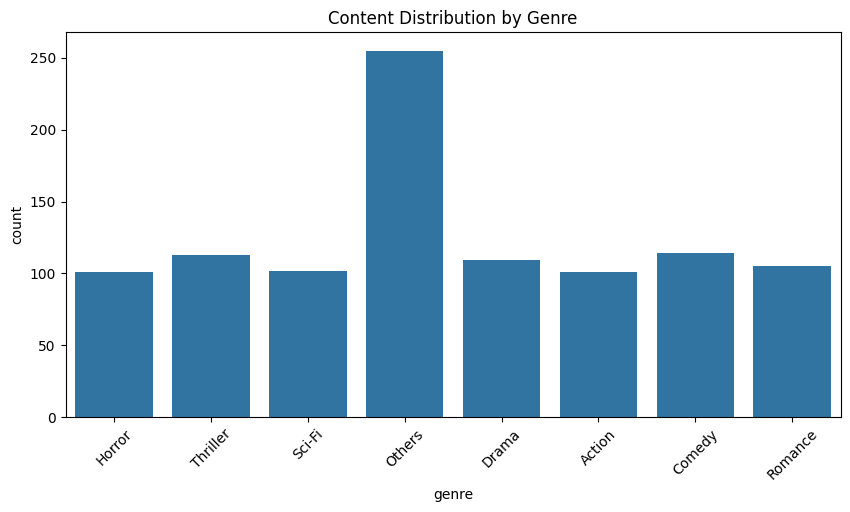

```python
plt.figure(figsize=(10,5))
# Accessing original categorical data to fix the plot while keeping the title
df_temp = pd.read_csv('/content/drive/MyDrive/ShowTime/ottdata.csv')
sns.countplot(data=df_temp, x='genre')
plt.xticks(rotation=45)
plt.title('Content Distribution by Genre')
plt.show()
```

**Observations:**

#### Day of Release

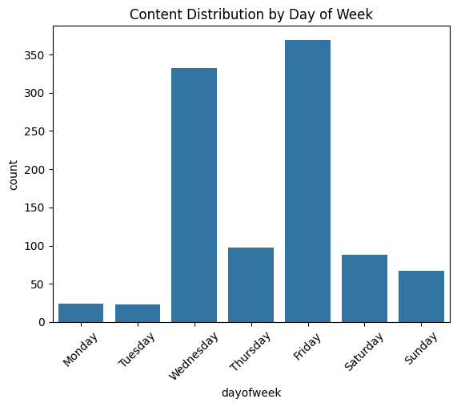

```python
df_temp = pd.read_csv('/content/drive/MyDrive/ShowTime/ottdata.csv')
sns.countplot(data=df_temp, x='dayofweek', order=['Monday', 'Tuesday', 'Wednesday', 'Thursday', 'Friday', 'Saturday', 'Sunday'])
plt.xticks(rotation=45)
plt.title('Content Distribution by Day of Week')
plt.show()
```

**Observations:**

- Content releases are not uniformly distributed throughout the week.
- A large proportion of content appears to be released on specific weekdays, particularly Friday and Wednesday.
- This suggests that the platform strategically schedules releases on days expected to attract higher audience engagement.
- Further analysis is required to determine whether these release days result in higher viewership.

#### Season

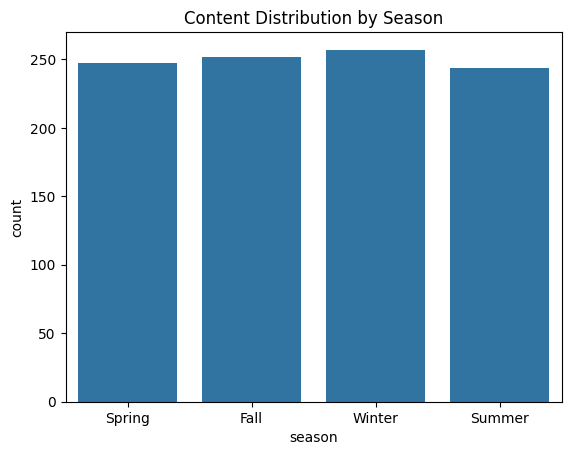

```python
df_temp = pd.read_csv('/content/drive/MyDrive/ShowTime/ottdata.csv')
sns.countplot(data=df_temp, x='season')
plt.title('Content Distribution by Season')
plt.show()
```

**Observations:**

- Content releases are fairly evenly distributed across all seasons.
- No season appears to dominate the release schedule.
- This balanced distribution allows the impact of seasonal effects on viewership to be analyzed without significant bias.
- Seasonal viewing behavior may influence audience consumption patterns.

#### Major Sports Events

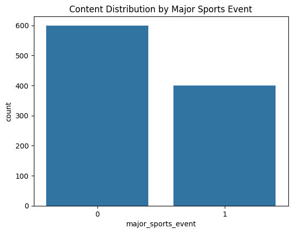

```python
sns.countplot(data=df, x="major_sports_event")
plt.title("Content Distribution by Major Sports Event")
plt.show()
```

**Observations:**

- The majority of content releases occur on days without major sports events.
- Only a smaller proportion of content is released during major sports events.
- This suggests that the platform may already be attempting to avoid competition with large sporting events.
- Since sports events can attract a substantial share of audience attention, their impact on content viewership should be examined further.

### Bivariate Analysis

#### Content Views vs Trailer Views

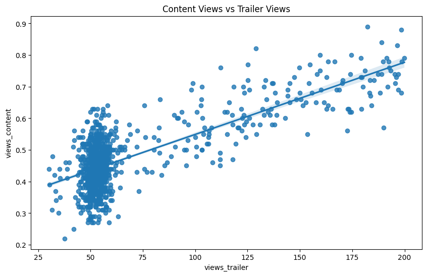

```python
plt.figure(figsize=(10, 6))
sns.regplot(x="views_trailer", y="views_content", data=df)
plt.title("Content Views vs Trailer Views")
plt.show()
```

**Observation:**

- A strong positive relationship is observed between trailer views and first-day content views.
- Content with higher trailer engagement generally tends to receive higher first-day viewership.
- This indicates that trailer popularity is a strong indicator of audience interest before release.
- The trend suggests that increasing trailer reach and engagement can significantly improve content performance.
- Trailer views are likely to be one of the most influential predictors in the regression model.

#### Content Views vs Visitors

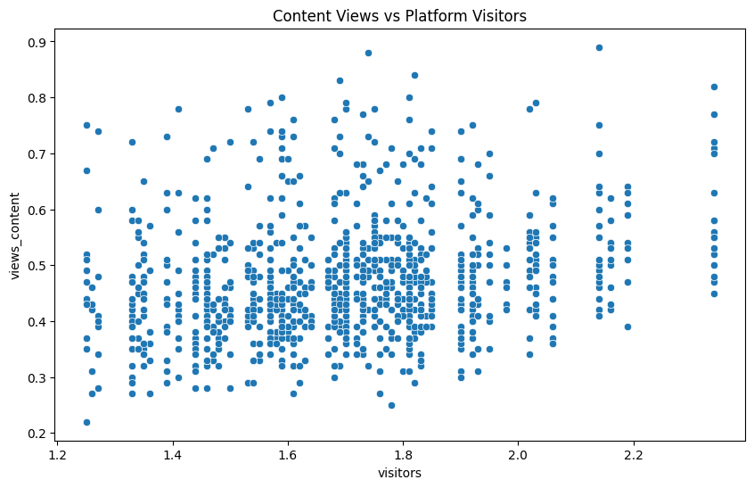

```python
plt.figure(figsize=(10, 6))
sns.scatterplot(x="visitors", y="views_content", data=df)
plt.title("Content Views vs Platform Visitors")
plt.show()
```

**Observation:**

- A positive relationship is observed between platform visitors and first-day content views.
- Content released during periods of higher platform traffic generally receives more views.
- This indicates that the overall audience size available on the platform influences content performance.
- However, the relationship is moderate rather than very strong, suggesting that additional factors also impact viewership.
- Increasing platform traffic before major releases may help improve content consumption.

#### Content Views vs Ad Impressions

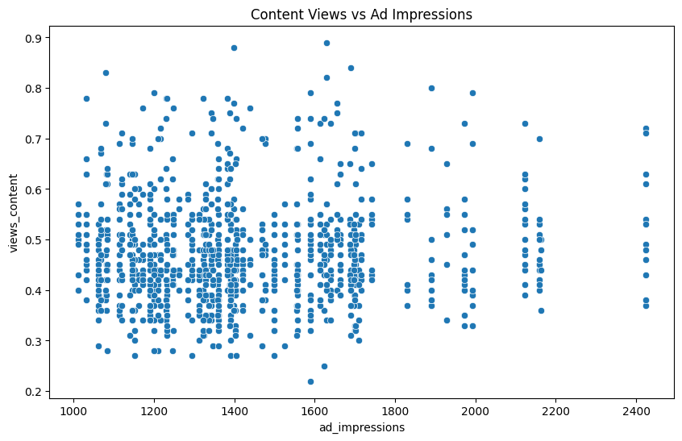

```python
plt.figure(figsize=(10, 6))
sns.scatterplot(x="ad_impressions", y="views_content", data=df)
plt.title("Content Views vs Ad Impressions")
plt.show()
```

**Observation:**

- The relationship between ad impressions and content views appears relatively weak.
- Although some highly advertised content receives good viewership, higher advertising exposure does not consistently translate into higher content views.
- This suggests that marketing alone may not guarantee audience engagement.
- Other factors such as content quality, genre preference, and trailer effectiveness may play a more significant role.

#### Content Views vs Major Sports Event

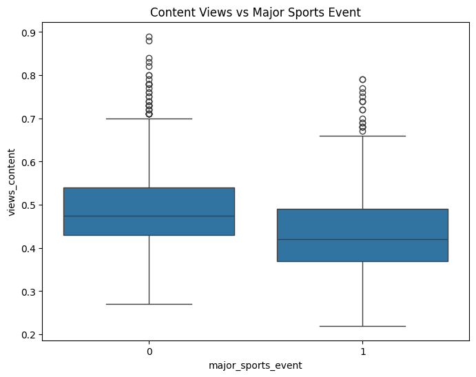

```python
plt.figure(figsize=(8, 6))
sns.boxplot(x="major_sports_event", y="views_content", data=df)
plt.title("Content Views vs Major Sports Event")
plt.show()
```

**Observation:**

- Content released on days with major sports events tends to receive lower first-day viewership compared to non-event days.
- This suggests that major sports events may divert audience attention away from OTT content.
- The difference in median viewership indicates a potential negative impact of sports-event competition.
- Releasing premium content during major sporting events may reduce audience engagement.

#### Content Views vs Genre

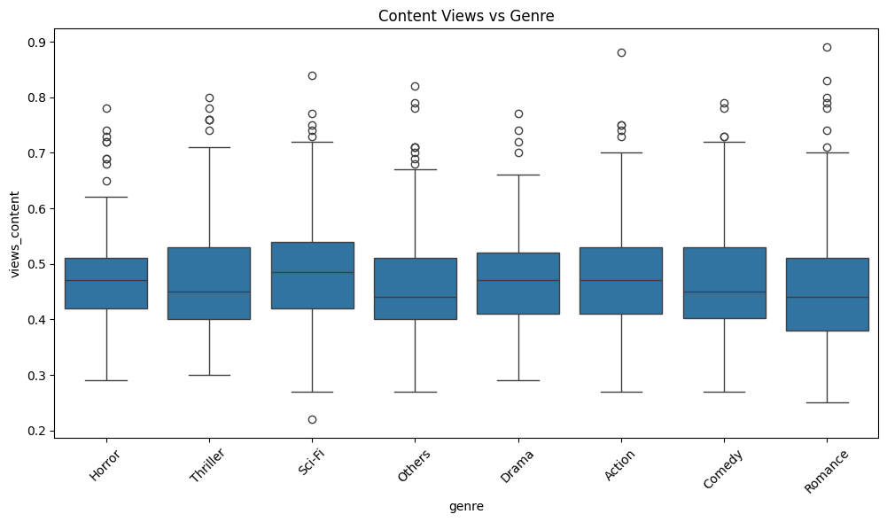

```python
plt.figure(figsize=(12, 6))
sns.boxplot(x="genre", y="views_content", data=df)
plt.xticks(rotation=45)
plt.title("Content Views vs Genre")
plt.show()
```

**Observation:**

#### Content Views vs Day of Week

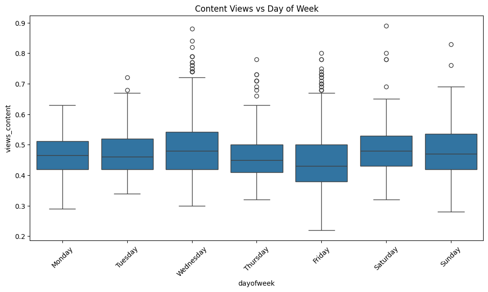

```python
plt.figure(figsize=(12, 6))
sns.boxplot(x="dayofweek", y="views_content", data=df, order=['Monday', 'Tuesday', 'Wednesday', 'Thursday', 'Friday', 'Saturday', 'Sunday'])
plt.xticks(rotation=45)
plt.title("Content Views vs Day of Week")
plt.show()
```

**Observation:**

#### Content Views vs Season

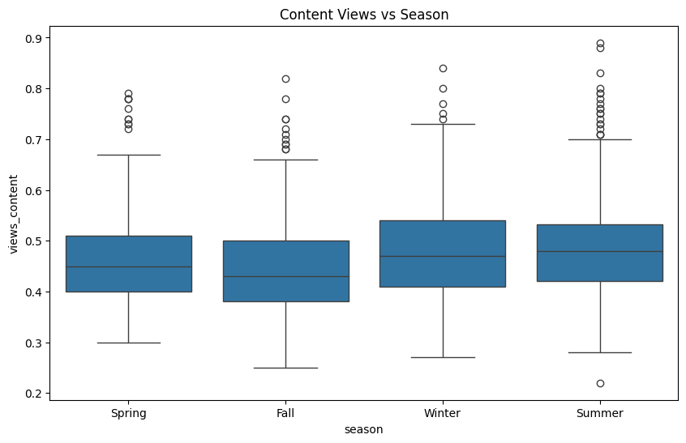

```python
plt.figure(figsize=(10, 6))
sns.boxplot(x="season", y="views_content", data=df)
plt.title("Content Views vs Season")
plt.show()
```

**Observation:**

- Content performance shows some variation across seasons.
- Seasonal differences may be driven by changes in audience behavior, holidays, or leisure time availability.
- Although the differences are not extremely large, seasonality may still contribute to overall performance.

#### Correlation Heatmap

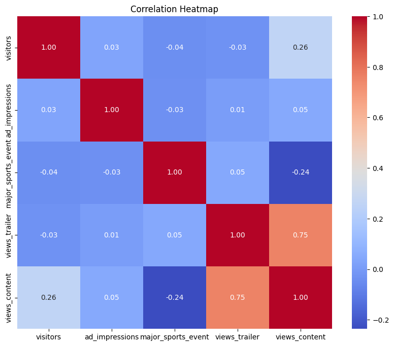

```python
plt.figure(figsize=(10, 8))
sns.heatmap(df.select_dtypes(include=[np.number]).corr(), annot=True, cmap="coolwarm", fmt=".2f")
plt.title("Correlation Heatmap")
plt.show()
```

**Observation:**

- Trailer views exhibit the strongest positive correlation with first-day content views among all numerical variables.
- Platform visitors also show a positive relationship with content views, although weaker than trailer views.
- Major sports events display a negative relationship with content viewership.
- No severe multicollinearity is observed among the predictor variables, indicating they can be used together in the regression model.

#### Pairplot Analysis

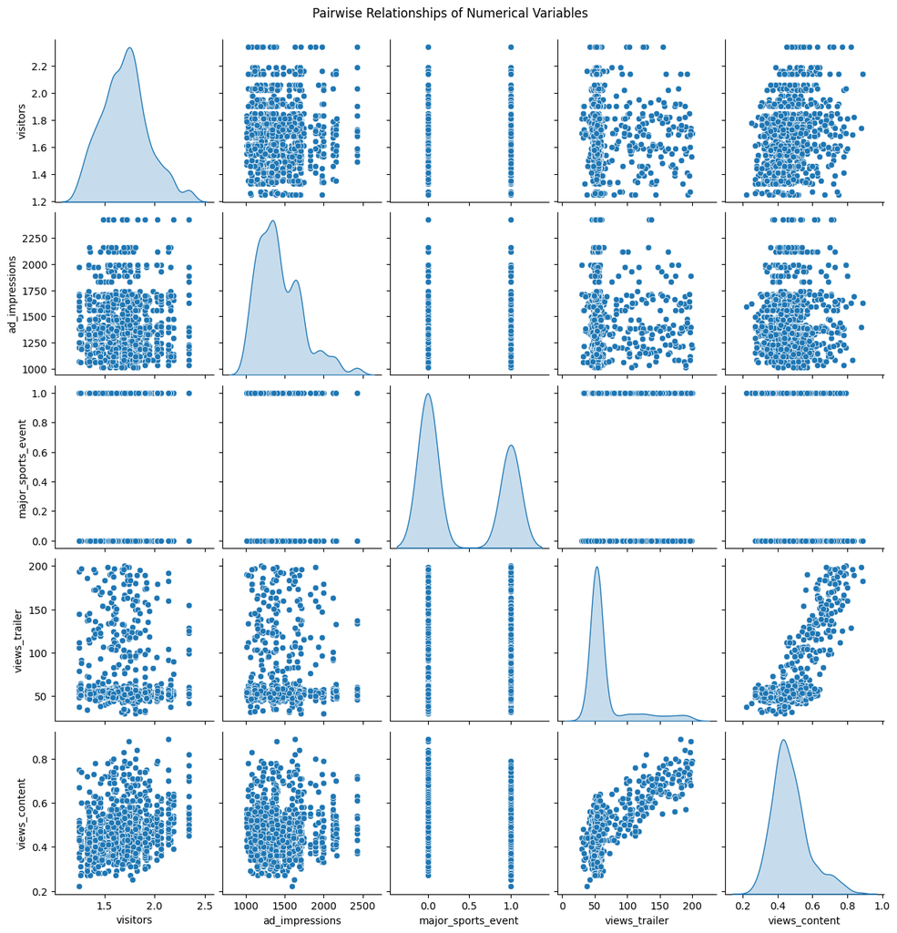

```python
sns.pairplot(df.select_dtypes(include=[np.number]), diag_kind='kde')
plt.suptitle("Pairwise Relationships of Numerical Variables", y=1.02)
plt.show()
```

**Observation:**

- Trailer views show the clearest linear relationship with content views.
- Visitors demonstrate a moderate positive association with content performance.
- Ad impressions do not exhibit a strong visible trend with content views.
- Most predictor variables appear to have independent relationships with the target variable.
- The pairwise relationships support the use of multiple linear regression for further analysis.

### Answers to Key Business Questions

**1. What does the distribution of content views look like?**

- The distribution of first-day content views is approximately normal with moderate variability.
- Most content receives average to moderate levels of first-day viewership, while only a small number of content releases achieve exceptionally high viewership.
- The distribution indicates that content performance varies considerably across releases, suggesting that multiple factors influence audience engagement.

**2. What does the distribution of genres look like?**

- Content is distributed across multiple genres, including Action, Comedy, Drama, Horror, Romance, Sci-Fi, Thriller, and Others.
- The genre distribution is relatively balanced, ensuring fair representation of different content categories.
- The "Others" category contains the highest number of content releases, while the remaining genres have comparable frequencies.

**4. How does viewership vary with the season of release?**

- Content viewership exhibits moderate variation across different seasons.
- Seasonal differences (with Summer and Winter performing strongly) demonstrate that audience availability and holidays contribute to content performance.

**5. What is the correlation between trailer views and content views?**

- Trailer views exhibit the strongest positive relationship with first-day content views (correlation coefficient ≈ 0.75).
- Content that generates higher trailer engagement before release tends to attract significantly more viewers on the first day.
- This suggests that trailer popularity is one of the most important drivers of content performance.

**Additional Insights from EDA**

- Platform visitors show a positive relationship with first-day content views, indicating that higher platform traffic contributes to increased content consumption.
- Major sports events negatively impact content viewership, suggesting that audience attention shifts toward live sporting events during such occasions.
- Ad impressions display a relatively weak direct relationship with content views, indicating that marketing exposure alone may not guarantee higher viewership.
- Genre, release timing, and seasonal factors also contribute to differences in content performance and should be considered when planning future content releases.

## Data Preprocessing

### Data Preparation

```python
# Defining the target variable and features
X = df.drop("views_content", axis=1)
y = df["views_content"]

print(f"Feature set shape: {X.shape}")
print(f"Target variable shape: {y.shape}")
```

[output not shown]

### Convert categorical variables

```python
df = pd.get_dummies(
    df,
    drop_first=True
)
```

#### Train-Test Split

Splitting the data into training (80%) and testing (20%) sets to evaluate model performance.

```python
X_train, X_test, y_train, y_test = train_test_split(
    X,
    y,
    test_size=0.20,
    random_state=1
)

print("X_train shape:", X_train.shape)
print("X_test shape:", X_test.shape)
print("y_train shape:", y_train.shape)
print("y_test shape:", y_test.shape)
```

[output not shown]

### Model Building

```python
lr = LinearRegression()
lr.fit(X_train, y_train)
```

```
LinearRegression()
```

#### Generate Predictions and Evaluate Performance (R²)

```python
from sklearn.metrics import r2_score

# Predictions
train_pred = lr.predict(X_train)
test_pred = lr.predict(X_test)

# R2 Score
print("Train R2:", r2_score(y_train, train_pred))
print("Test R2:", r2_score(y_test, test_pred))
```

```
Train R2: 0.7851433783851385
Test R2: 0.7827767529613896
```

#### Calculate RMSE

```python
from sklearn.metrics import mean_squared_error

rmse_train = np.sqrt(mean_squared_error(y_train, train_pred))
rmse_test = np.sqrt(mean_squared_error(y_test, test_pred))

print("Train RMSE:", rmse_train)
print("Test RMSE:", rmse_test)
```

```
Train RMSE: 0.0487681698536428
Test RMSE: 0.05051120738647075
```

#### Build OLS Model for Interpretation

Using `statsmodels` to identify driver variables through p-values and coefficients.

```python
# Adding a constant for the intercept term
X_train_sm = sm.add_constant(X_train)

# Converting to float to avoid object-type/boolean errors in statsmodels
X_train_sm = X_train_sm.astype(float)
y_train = y_train.astype(float)

# Fitting the OLS model
ols_model = sm.OLS(y_train, X_train_sm).fit()

print(ols_model.summary())
```

```
                            OLS Regression Results
==============================================================================
Dep. Variable:          views_content   R-squared:                       0.785
Model:                            OLS   Adj. R-squared:                  0.780
Method:                 Least Squares   F-statistic:                     142.3
Date:                Sun, 21 Jun 2026   Prob (F-statistic):          5.42e-244
Time:                        07:23:43   Log-Likelihood:                 1281.4
No. Observations:                 800   AIC:                            -2521.
Df Residuals:                     779   BIC:                            -2422.
Df Model:                          20
Covariance Type:            nonrobust
=======================================================================================
                          coef    std err          t      P>|t|      [0.025      0.975]
---------------------------------------------------------------------------------------
const                   0.0568      0.017      3.251      0.001       0.023       0.091
visitors                0.1254      0.007     16.925      0.000       0.111       0.140
ad_impressions       6.993e-06   6.16e-06      1.135      0.257    -5.1e-06    1.91e-05
major_sports_event     -0.0595      0.004    -16.277      0.000      -0.067      -0.052
views_trailer           0.0024   5.28e-05     44.706      0.000       0.002       0.002
genre_Comedy            0.0105      0.008      1.383      0.167      -0.004       0.025
genre_Drama             0.0134      0.008      1.752      0.080      -0.002       0.028
genre_Horror            0.0135      0.008      1.750      0.081      -0.002       0.029
genre_Others            0.0072      0.007      1.079      0.281      -0.006       0.020
genre_Romance          -0.0009      0.008     -0.114      0.909      -0.016       0.015
genre_Sci-Fi            0.0142      0.008      1.818      0.069      -0.001       0.030
genre_Thriller          0.0099      0.008      1.304      0.193      -0.005       0.025
dayofweek_Monday        0.0350      0.012      2.973      0.003       0.012       0.058
dayofweek_Saturday      0.0540      0.007      7.992      0.000       0.041       0.067
dayofweek_Sunday        0.0414      0.007      5.756      0.000       0.027       0.056
dayofweek_Thursday      0.0127      0.006      2.002      0.046       0.000       0.025
dayofweek_Tuesday       0.0194      0.012      1.601      0.110      -0.004       0.043
dayofweek_Wednesday     0.0461      0.004     10.978      0.000       0.038       0.054
season_Spring           0.0262      0.005      5.244      0.000       0.016       0.036
season_Summer           0.0449      0.005      8.754      0.000       0.035       0.055
season_Winter           0.0292      0.005      5.798      0.000       0.019       0.039
==============================================================================
Omnibus:                        2.662   Durbin-Watson:                   2.026
Prob(Omnibus):                  0.264   Jarque-Bera (JB):                2.515
Skew:                           0.131   Prob(JB):                        0.284
Kurtosis:                       3.085   Cond. No.                     1.68e+04
==============================================================================

Notes:
[1] Standard Errors assume that the covariance matrix of the errors is correctly specified.
[2] The condition number is large, 1.68e+04. This might indicate that there are
strong multicollinearity or other numerical problems.
```

**Observation :**

- The OLS summary provides coefficient estimates, p-values, and overall model statistics.
- Variables with statistically significant p-values contribute meaningfully to explaining content viewership.
- The coefficient values help quantify the impact of each predictor on first-day content views.

#### Model Coefficient Table

```python
coef_df = pd.DataFrame({
    'Variable': ols_model.params.index,
    'Coefficient': ols_model.params.values
})

display(coef_df.sort_values(by='Coefficient', ascending=False))
```

|  | Variable | Coefficient |
| --- | --- | --- |
| 1 | visitors | 0.125421 |
| 0 | const | 0.056798 |
| 13 | dayofweek_Saturday | 0.053973 |
| 17 | dayofweek_Wednesday | 0.046136 |
| 19 | season_Summer | 0.044900 |
| 14 | dayofweek_Sunday | 0.041414 |
| 12 | dayofweek_Monday | 0.035043 |
| 20 | season_Winter | 0.029234 |
| 18 | season_Spring | 0.026233 |
| 16 | dayofweek_Tuesday | 0.019445 |
| 10 | genre_Sci-Fi | 0.014186 |
| 7 | genre_Horror | 0.013544 |
| 6 | genre_Drama | 0.013434 |
| 15 | dayofweek_Thursday | 0.012660 |
| 5 | genre_Comedy | 0.010505 |
| 11 | genre_Thriller | 0.009945 |
| 8 | genre_Others | 0.007203 |
| 4 | views_trailer | 0.002360 |
| 2 | ad_impressions | 0.000007 |
| 9 | genre_Romance | -0.000899 |
| 3 | major_sports_event | -0.059487 |

**Coefficient Interpretation:**

- **views_trailer**: Strongest positive predictor; higher engagement pre-launch leads to higher views.
- **visitors**: Positive impact; platform traffic is a primary baseline for viewership.
- **major_sports_event**: Significant negative impact; competition for attention reduces OTT consumption.

## Linear Regression Assumptions

### Multicollinearity Check (VIF)

We check if independent variables are highly correlated with each other using the Variance Inflation Factor (VIF).

```python
from statsmodels.stats.outliers_influence import variance_inflation_factor

# Create a dataframe for VIF
vif = pd.DataFrame()
vif["Feature"] = X_train.columns
vif["VIF"] = [
    variance_inflation_factor(X_train.astype(float).values, i)
    for i in range(X_train.shape[1])
]

display(vif.sort_values("VIF", ascending=False))
```

|  | Feature | VIF |
| --- | --- | --- |
| 0 | visitors | 24.537103 |
| 1 | ad_impressions | 20.352512 |
| 3 | views_trailer | 4.812806 |
| 7 | genre_Others | 3.053057 |
| 19 | season_Winter | 2.123088 |
| 18 | season_Summer | 2.030598 |
| 10 | genre_Thriller | 2.024665 |
| 17 | season_Spring | 2.021802 |
| 5 | genre_Drama | 2.001160 |
| 9 | genre_Sci-Fi | 1.985362 |
| 4 | genre_Comedy | 1.980306 |
| 6 | genre_Horror | 1.974577 |
| 16 | dayofweek_Wednesday | 1.955559 |
| 8 | genre_Romance | 1.870416 |
| 2 | major_sports_event | 1.706007 |
| 14 | dayofweek_Thursday | 1.278545 |
| 12 | dayofweek_Saturday | 1.249170 |
| 13 | dayofweek_Sunday | 1.222921 |
| 15 | dayofweek_Tuesday | 1.087429 |
| 11 | dayofweek_Monday | 1.078489 |

**Observations on Multicollinearity:**

### Residual Normality

Residuals should follow an approximately normal distribution for valid statistical inference.

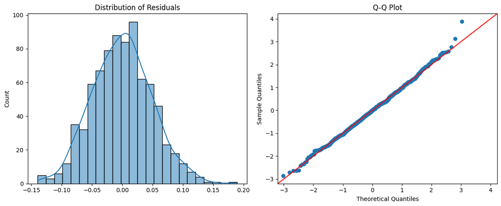

```python
# Residuals were previously defined but let's ensure they match the OLS model
y_train_pred = ols_model.predict(X_train_sm)
residuals = y_train - y_train_pred

plt.figure(figsize=(12, 5))

# Histogram
plt.subplot(1, 2, 1)
sns.histplot(residuals, kde=True)
plt.title("Distribution of Residuals")

# QQ Plot
plt.subplot(1, 2, 2)
sm.qqplot(residuals, line='45', fit=True, ax=plt.gca())
plt.title("Q-Q Plot")

plt.tight_layout()
plt.show()
```

**Observations on Residual Normality:**

- The **histogram** of residuals follows a distinct bell-shaped curve centered at zero, suggesting that errors are symmetrically distributed.
- The **Q-Q Plot** shows that most residuals lie directly on the 45-degree reference line, with only slight deviations at the extreme ends of the distribution.
- **Conclusion**: The assumption of normality is satisfied, ensuring that our p-values and confidence intervals for the model coefficients are reliable.

### Homoscedasticity and Linearity

We check for constant variance (homoscedasticity) and a linear relationship between actual and predicted values.

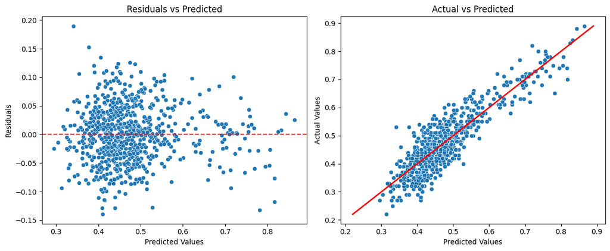

```python
plt.figure(figsize=(12, 5))

# Residual vs Predicted (Homoscedasticity)
plt.subplot(1, 2, 1)
sns.scatterplot(x=y_train_pred, y=residuals)
plt.axhline(y=0, color='red', linestyle='--')
plt.xlabel("Predicted Values")
plt.ylabel("Residuals")
plt.title("Residuals vs Predicted")

# Actual vs Predicted (Linearity)
plt.subplot(1, 2, 2)
sns.scatterplot(x=y_train_pred, y=y_train)
plt.plot([y_train.min(), y_train.max()], [y_train.min(), y_train.max()], color='red', lw=2)
plt.xlabel("Predicted Values")
plt.ylabel("Actual Values")
plt.title("Actual vs Predicted")

plt.tight_layout()
plt.show()
```

**Observations on Homoscedasticity and Linearity:**

- **Homoscedasticity**: In the 'Residuals vs Predicted' plot, the data points are randomly dispersed around the horizontal axis without forming any specific pattern (like a wedge or funnel). This indicates constant variance in the error terms.
- **Linearity**: The 'Actual vs Predicted' plot shows a strong diagonal alignment. The points follow the identity line closely, confirming that the relationship between the predictors and first-day viewership is inherently linear.

### Independence of Errors

We use the Durbin-Watson test to check for autocorrelation in residuals (values near 2.0 indicate independence).

```python
from statsmodels.stats.stattools import durbin_watson
dw_score = durbin_watson(residuals)
print(f"Durbin-Watson score: {dw_score:.4f}")
```

```
Durbin-Watson score: 2.0258
```

**Observations on Independence of Errors:**

- The calculated **Durbin-Watson score of 2.026** is very close to the ideal value of 2.0.
- This indicates that there is no significant autocorrelation present in the residuals, meaning each observation's error is independent of the others.